# 3. Futures

Investigate the mechanics and use of short selling S&P 500 futures contracts via the *Chicago Mercantile Exchange* (CME) as outlined in Document *A* of the case study.

The following investigation investigates futures prices of two contracts that would have been available during this time, i.e. *ESH20* and *ESM20*, with maturities in March and June, respectively. The trading prices for these contracts were sourced from [BarChart Premiere](https://www.barchart.com/stocks/quotes/$SPX%7C20241018%7C5720.00C/time-and-sales) historical data. A literature review (where relevant) and coding examples have been provided as part of this analysis.

### Key Assumptions & limitations

**Libraries**

```python
import yfinance as yf
import pandas as pd
import matplotlib.pyplot as plt
import matplotlib.dates as mdates
import matplotlib.ticker as ticker
import numpy as np
from datetime import datetime

import warnings
warnings.filterwarnings("ignore")
```

### 3.1 Hedging Position and Key details

To protect Pershing Square's portfolio from adverse market movements, they could utilise S&P 500 index futures contracts as a hedging instrument. This approach would allow the portfolio to gain protection against potential downside movements in the S&P 500

A futures contract is an agreement to buy or sell the underlying asset (in this case, the S&P 500 index) at a predetermined price on a specific date in the future. This allows the holder to lock in a price for the underlying asset, helping to protect against unfavorable price movements.

### Ongoing Cashflows and Costs

Since and observation of the payoff yield an immediate positive (and never a non-negative) payoff, we did not calculate any maintenance margin requires for these contracts.

### Futures Contract Payoff

The payoff of a futures contract at expiration depends on the relationship between the futures price ($S_F$) and the spot price of the underlying asset ($S_T$). If the spot price at expiration is higher than the agreed-upon futures price, the long position benefits, while the short position loses. Conversely, if the spot price is lower, the short position benefits.

The payoff of a short position futures contract is given by:

$$\text{Futures Contract Payoff} = K - S_T$$

Where:

- $S_T$ is the spot price of the S&P 500 index at expiration.
- $K$ is the agreed-upon futures price.

### Determining the Optimal Number of Contracts

To determine the optimal number of futures contracts required to hedge the portfolio, we can use the optimal hedging ratio. The goal is to align the portfolio's exposure to market movements with the performance of the hedging instrument (the S&P 500).

The optimal number of contracts $h$ can be calculated using the following formula:

Where:

- $h$ is the number of futures contracts to purchase or sell.
- $\beta$ is the beta of the portfolio relative to the S&P 500 (this measures the portfolio's sensitivity to market movements).
- $V$ is the value of the portfolio being hedged.
- $F$ is the notional value of one futures contract on the S&P 500 index, calculated as the index value multiplied by the contract multiplier.
- $\sigma _{A_t}$ is the standard deviation (volatility) in $A_t − A$.
- $\sigma _{K_t}$ is the standard deviation (volatility) in $K_t − K$.
- $\rho$ is the correlation between $A_t − A$ and $K_t − K$.

For the purposes of this assignment, $\sigma _{A_t}$, $\sigma _{K_t}$ and $\rho$ were calculated from historical daily returns in the prior four-year period (`HISTORICAL_PRICE_DATE`) to the evaluation date (`EVAL_DATE`).

```python
# Contract information
ESH20_CONTRACT_SIZE = 50
ESM20_CONTRACT_SIZE = 50
ESH20_HIST_PRICES = 'futures_data/esh20_price-history-09-24-2024.csv'
ESM20_HIST_PRICES = 'futures_data/esm20_price-history-09-24-2024.csv'
ESH20_MATURITY = '2020-03-30'
ESM20_MATURITY = '2020-06-30'
ESH20_INITIAL_MARGIN = 11_000.0
ESM20_INITIAL_MARGIN = 11_000.0

# Firm specific information
FIRM_VALUE = 7_621.28 * 1_000_000

# Contextual information
HISTORICAL_PRICE_DATE = '2016-01-04'
EVAL_DATE = '2020-02-21'
EVAL_DATE_PLUS_ONE = '2020-02-22'
EVAL_END_DATE = '2020-06-30'
```

**Calculate the portfolio value, weights, historical returns and standard deviations.**

This is a bit more complicated because the weighting for each firm in the portfolio varies as per the appendix provided on the assignment task sheet.

**Process:**

Import the historical prices for each firm, evaluate the firm value based upon the constituent assets owned in the portfolio and calculate the daily returns of the portfolio

```python
file_path = 'Perishing_portfolio.xlsx'
sheet_name = 'portfolio'
share_nums = {}

df = pd.read_excel(file_path, sheet_name=sheet_name)

for index, row in df.iterrows():
    ticker = row['Ticker Code']
    shares = row['Number of Shares']
    share_nums[ticker] = shares

# Also add the ^spx index
share_nums['^spx'] = 1

date_range = pd.date_range(start=HISTORICAL_PRICE_DATE, end=EVAL_END_DATE)
df = pd.DataFrame(index=date_range)

# stock prices for the evaluation period
for ticker, shares in share_nums.items():
    historical_data = yf.download(ticker, start=HISTORICAL_PRICE_DATE, end=EVAL_END_DATE)["Adj Close"]

    if not historical_data.empty:
        daily_values = historical_data * shares
        df[ticker] = daily_values

df = df.dropna(how='any')
df['Firm Value'] = df.loc[:, df.columns != '^spx'].sum(axis=1)
df_historic = df[df.index <= EVAL_DATE_PLUS_ONE]

df.index.name = 'Date'

p_returns = np.log(df_historic['Firm Value']).diff(1).dropna()
spx_returns = np.log(df_historic['^spx']).diff(1).dropna()

df_historic['Portfolio Returns'] = p_returns
df_historic['S&P 500 Returns'] = spx_returns
df_historic = df_historic.dropna()

# Portfolio price (we have discovered in previous sections)
p_price_eval_date = df_historic['Portfolio Returns'].loc[EVAL_DATE]

# Portfolio sigma
p_std_dev = np.std(p_returns)

# S&P 500 sigma
spx_std_dev = np.std(spx_returns)

# Safekeeping:
df_historic.to_excel('historic_portfolio_values.xlsx', sheet_name='Values')

df.head()
```

[output not shown]

| Date | CMG | HLT | LOW | QSR | BRK-B | HHH | A | FNMA | FMCC | ^spx | Firm Value |
| --- | --- | --- | --- | --- | --- | --- | --- | --- | --- | --- | --- |
| 2016-01-04 | 7.736718e+08 | 4.357516e+08 | 5.524744e+08 | 4.257521e+08 | 5.250389e+08 | 6.644987e+08 | 3.341809e+08 | 2.187775e+08 | 1.195375e+08 | 2012.660034 | 4.049683e+09 |
| 2016-01-05 | 7.740511e+08 | 4.359580e+08 | 5.536490e+08 | 4.094645e+08 | 5.270467e+08 | 6.575578e+08 | 3.330313e+08 | 2.227077e+08 | 1.202576e+08 | 2016.709961 | 4.033724e+09 |
| 2016-01-06 | 7.355062e+08 | 4.132306e+08 | 5.426402e+08 | 3.970094e+08 | 5.273680e+08 | 6.514694e+08 | 3.345095e+08 | 2.227077e+08 | 1.209777e+08 | 1990.260010 | 3.945419e+09 |
| 2016-01-07 | 7.171130e+08 | 3.977343e+08 | 5.289166e+08 | 3.879076e+08 | 5.199391e+08 | 6.362481e+08 | 3.203014e+08 | 2.161574e+08 | 1.173772e+08 | 1943.089966 | 3.841695e+09 |
| 2016-01-08 | 7.124415e+08 | 3.956681e+08 | 5.201833e+08 | 3.810812e+08 | 5.153212e+08 | 6.355175e+08 | 3.169340e+08 | 2.161574e+08 | 1.173772e+08 | 1922.030029 | 3.810681e+09 |

**Calculate optimal portfolio**

> Note: The notional value and initial margin are the same as both contracts have the same contract size

```python
# Calculate rho
rho=np.corrcoef(df_historic['S&P 500 Returns'], df_historic['Portfolio Returns'])[0 ,1]

# Firm portfolio value and returns
beta = rho * spx_std_dev / p_std_dev

# optimal hedge ratio
spx_price_eval_date = df_historic['^spx'].loc[EVAL_DATE]
F = spx_price_eval_date * ESM20_CONTRACT_SIZE #
H = beta * FIRM_VALUE / F

# Calculate initial margin
margin_cost_esm20 = H * ESM20_CONTRACT_SIZE
margin_cost_esh20 = H * ESH20_CONTRACT_SIZE
```

**Key Statistics**

```python
stats = f'''
############ KEY STATISTICS ############
Standard deviation of portfolio from historical date ({HISTORICAL_PRICE_DATE}) to evaluation date ({EVAL_DATE}): {p_std_dev:.6f}
Standard deviation of S&P 500 Sigma from historical date ({HISTORICAL_PRICE_DATE}) to evaluation date ({EVAL_DATE}): {spx_std_dev:.6f}
Rho: {rho:.6f}
Beta: {beta:.6f}

Face value of futures contract on evaluation date ({EVAL_DATE}): ${F:.2f}


Optimal number of contracts to hedge firm position: {int(round(H, 0))}
(unrounded {H:.2f})

############ INITIAL MARGIN ############
Initial Margin (ESM20): {margin_cost_esm20:.2f}
Initial Margin (ESH20): {margin_cost_esh20:.2f}
'''

print(stats)
```

```
############ KEY STATISTICS ############
Standard deviation of portfolio from historical date (2016-01-04) to evaluation date (2020-02-21): 0.010099
Standard deviation of S&P 500 Sigma from historical date (2016-01-04) to evaluation date (2020-02-21): 0.008079
Rho: 0.741110
Beta: 0.592861

Face value of futures contract on evaluation date (2020-02-21): $166887.50


Optimal number of contracts to hedge firm position: 27074
(unrounded 27074.27)

############ INITIAL MARGIN ############
Initial Margin (ESM20): 1353713.70
Initial Margin (ESH20): 1353713.70
```

### 3.2 (Retrospective) Key Timings

We will characterise the best exit timing of these securities as the date which would yield the maximum payoff between the evaluation date and maturity.

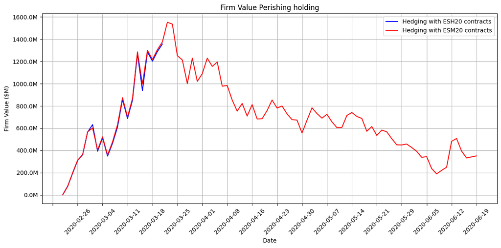

```python
import matplotlib.ticker as ticker
# Retrieve historic futures data for ESH20 and ESM20

def generate_futures_payoffs(historical_prices_wd, contract_size):

    futures_prices_df = pd.read_csv(historical_prices_wd, index_col='Time', parse_dates=['Time'])['Open'].to_frame()
    futures_prices_df = futures_prices_df[futures_prices_df.index >= EVAL_DATE]
    futures_prices_df.index = pd.to_datetime(futures_prices_df.index).strftime('%Y-%m-%d')
    futures_prices_df = futures_prices_df.sort_index()
    futures_prices_df = futures_prices_df.rename(columns={'Open': 'Price'})

    esh20_eval_date = futures_prices_df['Price'].loc[EVAL_DATE]

    futures_prices_df['Payoff from EVAL_DATE'] = (esh20_eval_date - futures_prices_df['Price']) * (H * contract_size)
    return futures_prices_df

esh20_prices_df = generate_futures_payoffs(ESH20_HIST_PRICES, ESH20_CONTRACT_SIZE)
esm20_prices_df = generate_futures_payoffs(ESM20_HIST_PRICES, ESM20_CONTRACT_SIZE)

plt.figure(figsize=(12, 6))
plt.plot(esh20_prices_df.index, esh20_prices_df['Payoff from EVAL_DATE'], linestyle='-', color='b', label='Hedging with ESH20 contracts')
plt.plot(esm20_prices_df.index, esm20_prices_df['Payoff from EVAL_DATE'], linestyle='-', color='r', label='Hedging with ESM20 contracts')
plt.title('Firm Value Perishing holding')
plt.xlabel('Date')
plt.ylabel('Firm Value ($M)')
plt.xticks(rotation=45)
plt.gca().xaxis.set_major_locator(mdates.DayLocator(interval=5))
plt.gca().yaxis.set_major_formatter(ticker.FuncFormatter(lambda x, pos: f'{x*1e-6:.1f}M'))
plt.grid()
plt.legend()
plt.tight_layout()
plt.show()
```

```python
# The best date to close the futures contract with a reversing trade would be:
max_price_date = esm20_prices_df['Payoff from EVAL_DATE'].idxmax()

print(f'The best exit timing of the market would be {max_price_date.strftime('%Y-%m-%d')}.')
```

```
The best exit timing of the market would be 2020-03-23.
```

### 3.3 Profits

We now consider the overall profits of Pershing Square maintaining their current portfolio and the futures hedging position.

The profit diagram of their firm is illustrated is the worked coding example below.

```python
# Given the payoff diagram above, we will only look at the ESM20 contract since the payoffs are similar and it gives up a longer time horizon.
df_profits = df[df.index >= EVAL_DATE].copy()
df_profits = df_profits[['Firm Value']]

# Shuffling because the data isn't perfect
df_profits.index = pd.to_datetime(df_profits.index).normalize()
esm20_prices_df.index = pd.to_datetime(esm20_prices_df.index).normalize()
aligned_esm20_payoff = esm20_prices_df['Payoff from EVAL_DATE'].reindex(df_profits.index)

df_profits.loc[:, 'ESM Payoff'] = aligned_esm20_payoff

firm_value_eval_date = df_profits['Firm Value'].loc[EVAL_DATE]
df_profits['Firm Profit'] = df_profits['Firm Value'] - firm_value_eval_date
df_profits['Firm Profit With Futures Hedge'] = df_profits['ESM Payoff'] + df_profits['Firm Profit']
df_profits['Firm Value With Futures Hedge'] = df_profits['ESM Payoff'] + df_profits['Firm Value']

df_profits.head()
```

| Date | Firm Value | ESM Payoff | Firm Profit | Firm Profit With Futures Hedge | Firm Value With Futures Hedge |
| --- | --- | --- | --- | --- | --- |
| 2020-02-21 | 7.696251e+09 | 0.000000e+00 | 0.000000e+00 | 0.000000e+00 | 7.696251e+09 |
| 2020-02-24 | 7.429246e+09 | 7.513111e+07 | -2.670049e+08 | -1.918738e+08 | 7.504377e+09 |
| 2020-02-25 | 7.145713e+09 | 1.996728e+08 | -5.505380e+08 | -3.508652e+08 | 7.345386e+09 |
| 2020-02-26 | 7.038965e+09 | 3.123694e+08 | -6.572857e+08 | -3.449162e+08 | 7.351335e+09 |
| 2020-02-27 | 6.684721e+09 | 3.631337e+08 | -1.011530e+09 | -6.483962e+08 | 7.047855e+09 |

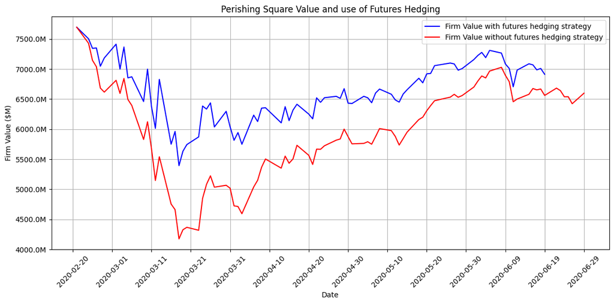

```python
plt.figure(figsize=(12, 6))
plt.plot(df_profits.index, df_profits['Firm Value With Futures Hedge'], linestyle='-', color='b', label='Firm Value with futures hedging strategy')
plt.plot(df_profits.index, df_profits['Firm Value'], linestyle='-', color='r', label='Firm Value without futures hedging strategy')
plt.title('Perishing Square Value and use of Futures Hedging')
plt.xlabel('Date')
plt.ylabel('Firm Value ($M)')
plt.xticks(rotation=45)
plt.gca().xaxis.set_major_locator(mdates.DayLocator(interval=10))
plt.gca().yaxis.set_major_formatter(ticker.FuncFormatter(lambda x, pos: f'{x*1e-6:.1f}M'))
plt.grid()
plt.legend()
plt.tight_layout()
plt.show()
```

### 3.4 Sensitivity Analysis

A futures contract can be priced using the cost of carry approach

$$K = Se^{(r+s−q)T}$$ (using **Compound Interest**)

i.e. that the futures price is dependent on the risk-free interest rate $r$, storage cost $c$ and dividend yield $q$ in some period $T$.

#### 3.4.1 Forecast Changes in Cost of Carry

The following code example forecasts changes in the estimated cost of carry:

- The cost of carry is first derived as of the evaluation date (February 21, 2020).
- The payoffs are then evaluated under different cost of carry values, considering forecast periods of one week, one month, and two months into the future.

```python
eval_date_as_date = datetime.strptime(EVAL_DATE, '%Y-%m-%d')
esm20_maturity_as_date = datetime.strptime(ESM20_MATURITY, '%Y-%m-%d')

T = (esm20_maturity_as_date - eval_date_as_date).days / 360

K = esm20_prices_df['Price'].loc[EVAL_DATE]
S = spx_price_eval_date

cost_of_carry = np.log((K / S))* (1 / T)

print(f'K: {K} \nS: {S}\nT: {T}\nCost of Carry: {cost_of_carry:3f}')
```

```
K: 3367.5
S: 3337.75
T: 0.3611111111111111
Cost of Carry: 0.024573
```

```python
min_value = cost_of_carry - 0.25
max_value = cost_of_carry + 0.1

T_after_one_week = ((esm20_maturity_as_date - eval_date_as_date).days - 7) / 360
T_after_one_month = ((esm20_maturity_as_date - eval_date_as_date).days - 30) / 360
T_after_two_months = ((esm20_maturity_as_date - eval_date_as_date).days - 60) / 360

sensitivity_values = np.linspace(min_value, max_value, 50)
df_sensitivity = pd.DataFrame(sensitivity_values, columns=['Cost Of Carry'])
df_sensitivity['K One Week Forecast'] = S * np.exp(df_sensitivity['Cost Of Carry'] * T_after_one_week)
df_sensitivity['K One Month Forecast'] = S * np.exp(df_sensitivity['Cost Of Carry'] * T_after_one_month)
df_sensitivity['K Two Month Forecast'] = S * np.exp(df_sensitivity['Cost Of Carry'] * T_after_two_months)

df_sensitivity.head()
```

|  | Cost Of Carry | K One Week Forecast | K One Month Forecast | K Two Month Forecast |
| --- | --- | --- | --- | --- |
| 0 | -0.225427 | 3090.324643 | 3135.154350 | 3194.606642 |
| 1 | -0.218284 | 3097.875717 | 3141.381070 | 3199.046678 |
| 2 | -0.211141 | 3105.445242 | 3147.620157 | 3203.492885 |
| 3 | -0.203998 | 3113.033263 | 3153.871634 | 3207.945272 |
| 4 | -0.196855 | 3120.639824 | 3160.135528 | 3212.403847 |

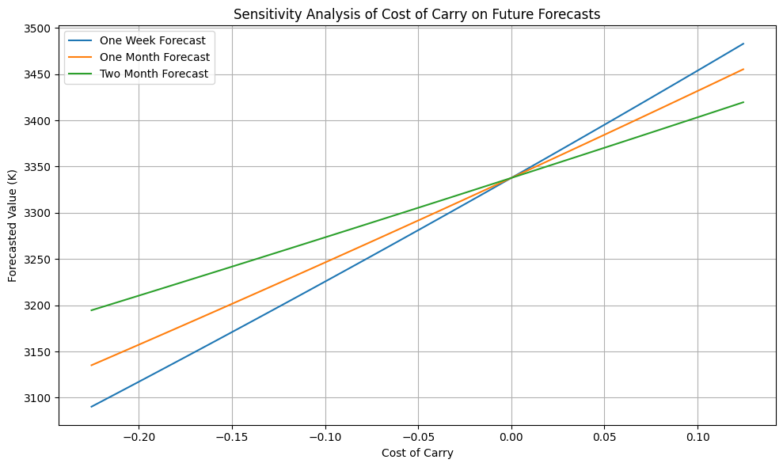

```python
plt.figure(figsize=(10, 6))
plt.plot(df_sensitivity['Cost Of Carry'], df_sensitivity['K One Week Forecast'], label='One Week Forecast')
plt.plot(df_sensitivity['Cost Of Carry'], df_sensitivity['K One Month Forecast'], label='One Month Forecast')
plt.plot(df_sensitivity['Cost Of Carry'], df_sensitivity['K Two Month Forecast'], label='Two Month Forecast')
plt.title('Sensitivity Analysis of Cost of Carry on Future Forecasts')
plt.xlabel('Cost of Carry')
plt.ylabel('Forecasted Value (K)')
plt.legend()
plt.grid(True)


plt.tight_layout()
plt.show()
```

### 3.5 Acknowledgements and Tooling

This work is licensed under the MIT License and is freely available for distribution. All rights are reserved by the author, DanielCiccC.

- Various tools, including GitHub, GitHub Copilot, and ChatGPT, were utilised in the development and analysis of this project.
- Portions of the code were adapted from examples provided in lectures.

[output not shown]